# MixedTypeData

Zhiwen Tan

## Introduction

`BCClong` is an R package for performing Bayesian Consensus Clustering (BCC) model for clustering continuous, discrete and categorical longitudinal data, which are commonly seen in many clinical studies. This document gives a tour of BCClong package.

see `help(package = "BCClong")` for more information and references provided by `citation("BCClong")`

To download **BCClong**, use the following commands:

```r
require("devtools")
devtools::install_github("ZhiwenT/BCClong", build_vignettes = TRUE)
library("BCClong")
```

To list all functions available in this package:

```r
ls("package:BCClong")
```

## Components

Currently, there are 5 function in this package which are *BCC.multi*, *BayesT*, *model.selection.criteria*, *traceplot*, *trajplot*.

*BCC.multi* function performs clustering on mixed-type (continuous, discrete and categorical) longitudinal markers using Bayesian consensus clustering method with MCMC sampling and provide a summary statistics for the computed model. This function will take in a data set and multiple parameters and output a BCC model with summary statistics.

*BayesT* function assess the model goodness of fit by calculate the discrepancy measure T(, ) with following steps (a) Generate T.obs based on the MCMC samples (b) Generate T.rep based on the posterior distribution of the parameters (c) Compare T.obs and T.rep, and calculate the P values.

*model.selection.criteria* function calculates DIC and WAIC for the fitted model *traceplot* function visualize the MCMC chain for model parameters *trajplot* function plot the longitudinal trajectory of features by local and global clustering

## Pre-process (Setting up)

In this example, the `PBCseq` data in the `mixAK` package was used as it is a public data set. The variables used here include lbili, platelet, and spiders. Of these three variables, lbili and platelet are continuous variables, while spiders are categorical variables.

```r
library(BCClong)
library(mixAK)
data(PBC910)
```

## Fit BCC Model Using BCC.multi Function

Here, We used a binomial distribution for spiders marker, a gaussian distribution for the lbili marker and poisson distribution for platelet, respectively. The number of clusters was set to 2. All hyper parameters were set to default.

We ran the model with 12,000 iterations, discard the first 2,000 sample, and kept every 10th sample. This resulted in 1,000 samples for each model parameter. The MCMC sampling process took about 30 minutes on an AMD Ryzen$^{TM}$ 5 5600X desktop computer.

Since this program takes a long time to run, here we will use the pre-compile result in this example.

```r
set.seed(89)
fit.BCC2 <- BCC.multi(
    mydat = list(PBC910$lbili,PBC910$platelet,PBC910$spiders),
    dist = c("gaussian","poisson","binomial"),
    id = list(PBC910$id),
    time = list(PBC910$month),
    formula =list(y ~ time + (1|id),y ~ time + (1|id), y ~ time + (1|id)),
    num.cluster = 2,
    burn.in = 100,
    thin = 10,
    per = 10,
    max.iter = 200)
```

To run the pre-compiled result, you can use `data(PBCseqfit)` to attach the fitted model.

```r
# pre-compiled result
data(PBCseqfit)
fit.BCC2 <- PBCseqfit
```

## Printing Summary Statistics for key model parameters

To print the BCC model

```r
print(fit.BCC2)
```

To print the summary statistics for all parameters

```r
summary(fit.BCC2)
```

To print the proportion for each cluster (mean, sd, 2.5% and 97.5% percentile) geweke statistics (geweke.stat) between -2 and 2 suggests the parameters converge

```r
fit.BCC2$summary.stat$PPI
```

The code below prints out all major parameters

```r
summary(fit.BCC2)
```

```
#> Total number of individual:
#> [1] 260
#>
#> Number of features:
#> [1] 3
#>
#> Cluster proportions statistics for global clusters:
#>        V1               V2
#>  Min.   :0.8496   Min.   :0.005276
#>  1st Qu.:0.8762   1st Qu.:0.043312
#>  Median :0.9371   Median :0.062932
#>  Mean   :0.9216   Mean   :0.078430
#>  3rd Qu.:0.9567   3rd Qu.:0.123799
#>  Max.   :0.9947   Max.   :0.150384
#>
#> Globle clusters table:
#>
#>   1
#> 260
#>
#> Adherence parameters statistics by feature:
#>        V1               V2               V3
#>  Min.   :0.5007   Min.   :0.5001   Min.   :0.7772
#>  1st Qu.:0.5021   1st Qu.:0.5089   1st Qu.:0.7902
#>  Median :0.5030   Median :0.5115   Median :0.7959
#>  Mean   :0.5042   Mean   :0.5175   Mean   :0.8078
#>  3rd Qu.:0.5041   3rd Qu.:0.5237   3rd Qu.:0.8275
#>  Max.   :0.5118   Max.   :0.5583   Max.   :0.8576
#>
#> Local clusters statistics by feature:
#> Cluster statistics for feature 1 :
#> , , 1
#>
#>                    [,1]        [,2]
#> mean         1.46526216 -0.14926529
#> sd           0.03777137  0.01364611
#> 2.5%         1.40888462 -0.16946273
#> 97.5%        1.51895826 -0.13096229
#> geweke.stat -2.10391018 -1.75995576
#>
```

[output cut: 118 more lines]

```
#> NULL
#>
#> Local clusters tables by feature:
#> Clusters table for feature 1 :
#>
#>   1   2
#>  86 174
#> Clusters table for feature 2 :
#>
#>   1   2
#> 126 134
#> Clusters table for feature 3 :
#>
#>   1   2
#> 198  62
```

## Visualize Clusters

Generic plot can be used on BCC object, all relevant plots will be generate one by one using return key

```r
plot(fit.BCC2)
```

We can use the *traceplot* function to plot the MCMC process and the *trajplot* function to plot the trajectory for each feature.

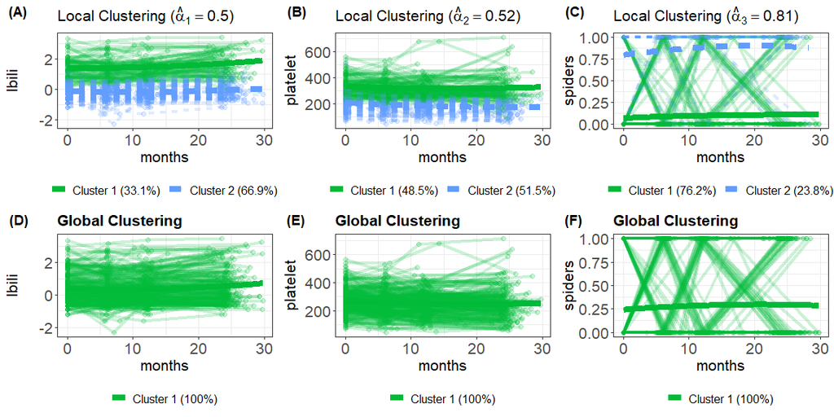

```r
gp1 <- trajplot(fit=fit.BCC2,feature.ind=1,which.cluster = "local.cluster",
            title= bquote(paste("Local Clustering (",hat(alpha)[1] ==.(round(fit.BCC2$alpha[1],2)),")")),
            xlab="months",ylab="lbili",color=c("#00BA38", "#619CFF"))
gp2 <- trajplot(fit=fit.BCC2,feature.ind=2,which.cluster = "local.cluster",
            title= bquote(paste("Local Clustering (",hat(alpha)[2] ==.(round(fit.BCC2$alpha[2],2)),")")),
            xlab="months",ylab="platelet",color=c("#00BA38", "#619CFF"))
gp3 <- trajplot(fit=fit.BCC2,feature.ind=3,which.cluster = "local.cluster",
            title= bquote(paste("Local Clustering (",hat(alpha)[3] ==.(round(fit.BCC2$alpha[3],2)),")")),
            xlab="months",ylab="spiders",color=c("#00BA38", "#619CFF"))
gp4 <- trajplot(fit=fit.BCC2,feature.ind=1,which.cluster = "global.cluster",
            title="Global Clustering",
            xlab="months",ylab="lbili",color=c("#00BA38", "#619CFF"))
gp5 <- trajplot(fit=fit.BCC2,feature.ind=2,which.cluster = "global.cluster",
            title="Global Clustering",
            xlab="months",ylab="platelet",color=c("#00BA38", "#619CFF"))
gp6 <- trajplot(fit=fit.BCC2,feature.ind=3,which.cluster = "global.cluster",
            title="Global Clustering",
            xlab="months",ylab="spiders",color=c("#00BA38", "#619CFF"))

library(cowplot)
#dev.new(width=180, height=120)
plot_grid(gp1, gp2,gp3,gp4,gp5,gp6,
          labels=c("(A)", "(B)", "(C)", "(D)", "(E)", "(F)"), ncol = 3,   align = "v" )
```

## Package References

[Tan, Z., Shen, C., Lu, Z. (2022) BCClong: an R package for performing Bayesian Consensus Clustering model for clustering continuous, discrete and categorical longitudinal data.](https://github.com/ZhiwenT/BCClong)